# SQL Lesson 1

2/23/2021

## Introduction

## Introduction

### Roadmap

- Introducing Scenario
- Database Concepts & Motivation
- Data Model
- SQL
  - Language
  - SELECT
  - WHERE
  - GROUP BY

## Introduction

### Our Scenario Today

We are running a bookstore collectively (just like the left-wing leaning bookstore on campus **The Groundwork Books Collective**). How do you manage your book inventory?

- What are some **common operations** that you want to do to your inventory? (CRUD)
- What are some **tool(s)** that you can think of to support your operation on the inventory?
- With these tool(s), what are some **problems** that might emerge in the foreseeable future?

Using database and database management system, many of these concerns will be addressed.

Note: These problems and solutions are generalizable.

## Introduction

### Database related concepts

- **Database**: Shared collection of related data used to support the activities of a particular organization.
- **Database Management System(DBMS)**: Programs that support CRUD operations and control all access to databases.
  - Provide an environment that is both **convenient** and **efficient** for users to retrieve and store information
- **SQL**: Structured Query Language - language used to talk to DBMS

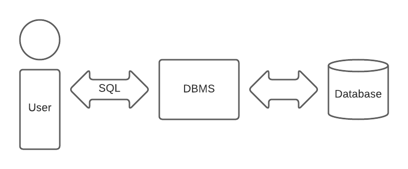

## Introduction

### Formalized Motivation

- **Automation**. Interface linking to other programs
- **Summary Statistics**. Help you generate the report
- **Enforcement of Integrity constraints**. Rules to constraints that users enter valid information (**data type!**)
- **Multiuser system**. Control for access, data sharing
  - e.g. Read and write, read-only
- **Backup and recovery facilities**.

## Data Model

## Data model

### A bird-eye view of our data

```r
books
```

```
## # A tibble: 13 x 5
##    title               author        ISBN13    avg_rating publisher
##    <chr>               <chr>         <chr>          <dbl> <chr>
##  1 Beyond Good and Ev~ Friedrich Ni~ 97806797~       3.99 Vintage
##  2 Sanshiro            Natsume Sose~ 97819292~       3.83 Center for Japanese S~
##  3 The World of Yeste~ Stefan Zweig  97808032~       4.49 University of Nebrask~
##  4 Chronicle of the N~ Alvar Nunez ~ 97801424~       3.66 Penguin Classics
##  5 The Epic of Gilgam~ Anonymous     97801410~       3.7  Penguin Books Limited
##  6 Letter from an Unk~ Stefan Zweig  97819065~       4.23 Pushkin Press
##  7 Gorgias             Plato         97801404~       3.96 Penguin Classics
##  8 Twelfth Night       William Shak~ 97807434~       3.98 Simon Schuster
##  9 Leviathan           Thomas Hobbes 97801404~       3.71 Penguin Books
## 10 The Essays: A Sele~ Michel de Mo~ 97801404~       4.07 Penguin Classics
## 11 The Prince          Niccolo Mach~ 97801404~       3.82 Penguin Group
## 12 Second Treatise of~ John Locke    97809151~       3.77 Hackett Publishing Co~
## 13 Candide and Relate~ Voltaire      97808722~       3.81 Hackett Publishing Co~
```

```r
customers
```

```
## # A tibble: 5 x 5
##      id first   last       purchase_number      fav_book
##   <dbl> <chr>   <chr>                <dbl>         <dbl>
## 1 11111 Philip  Fry                      2 9780872205468
## 2 11112 Turanga Leela                    1 9780141026282
## 3 11113 Hubert  Farnsworth               3 9780140449150
## 4 11114 Amy     Wong                     2 9781929280100
## 5 11115 Hermes  Conrad                   1 9780142437070
```

```r
transactions
```

```
## # A tibble: 8 x 3
##   transaction_id customer_id          ISBN
##            <dbl>       <dbl>         <dbl>
## 1              1       11111 9780872205468
## 2              2       11111 9780140449044
## 3              3       11112 9780141026282
## 4              4       11113 9780140449150
## 5              5       11113 9780872205468
## 6              6       11114 9781929280100
## 7              7       11114 9780743482776
## 8              8       11115 9780142437070
```

## Data Model

### Entity-Relationship Diagram

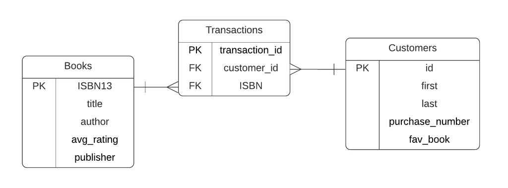

## Data Model

### Anatomy of a Database

- **Primary Key**: The column that uniquely identify each row in a table
- **Foreign Key**: A column in a table that references the primary key in another table

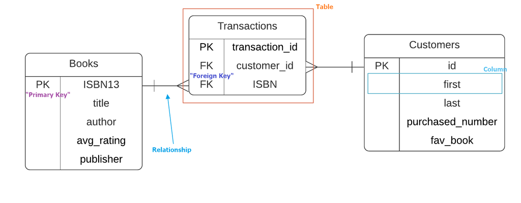

**Question**: There is a missing relation. Can you spot it?

## SQL

### Introduction

- SQL is formally defined, but implemented differently
  - **Incompatibility**, but very similar. You only need to learn it once.
  - Popular Extensions: MySQL, PostgreSQL,
  - We will be using **SQLite**
- Run from
1. command line prompt
2. Dedicated Program like DB Browser
3. Other programming languages such as Python and R, with dedicated libraries

## SQL

### Language & Syntax

- **Case Insensitive!**
  - UPPERCASE FOR KEYWORDS
  - lowercase for anything else
- End your statement with ‘;’
  - empowers nice formatting

## A Tour of DB Browser

### Open Existing Database

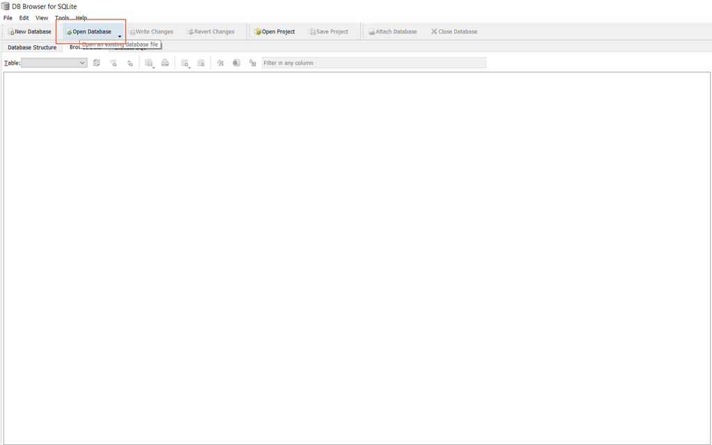

## A Tour of DB Browser

### Database Structure

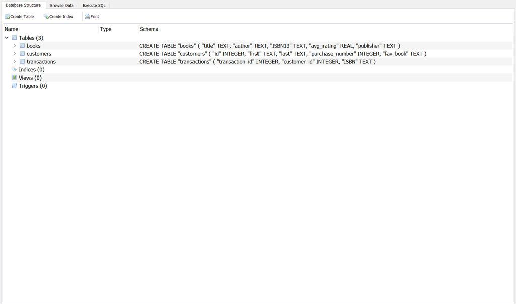

## A Tour of DB Browser

### Browse Data

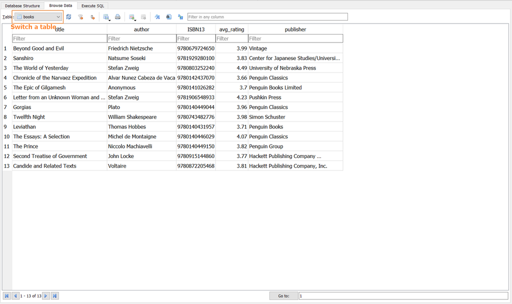

## A Tour of DB Browser

### Execute SQL

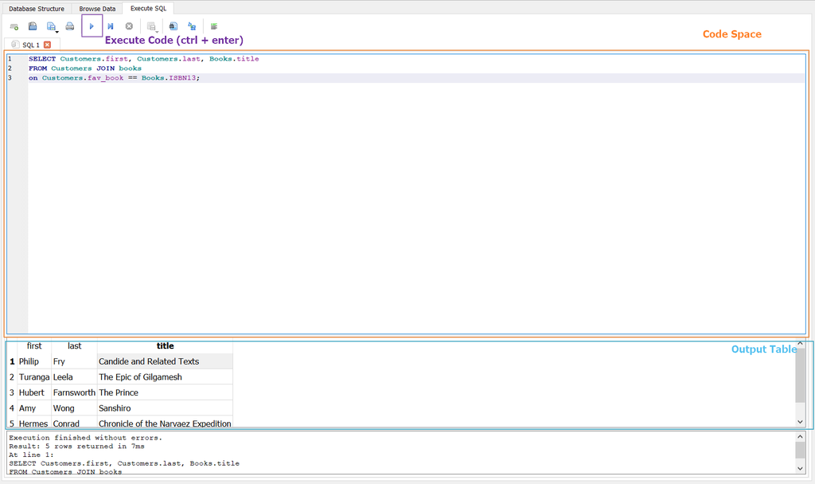

## Non-relational Operations

### Overview

- If you have taken the R module, you know them all already

[figure not shown]

## Non-relational Operations

### Overview

- Select columns: SELECT column(s) FROM table
- Select unique rows: SELECT distinct rows from your table
- Sort by a column: ORDER BY a column
- Filter rows by a condition: WHERE [criteria]
- Calculate new values on the fly
- Calculate summary statistics with functions
- Aggregate over groups: GROUP BY

## SELECT

```sql
-- syntax
SELECT [column(s)] FROM table;
```

Select ‘title’ and ‘author’ column from table ‘books’

```sql
SELECT title, author FROM books;
```

In R:

```r
books %>% select(title, author)
```

## SELECT

### SELECT *

- Select all columns in a table
- Note ’*’ is called wild card

```sql
-- syntax
SELECT * FROM [table]
```

Select all columns in table books

```sql
SELECT * FROM books;
```

```r
books %>% select_all()
```

## SELECT

### SELECT DISTINCT

Select distinct rows from selected column(s) in a table

```sql
SELECT DISTINCT [column(s)] FROM [table];
```

**Question**: How many books are sold (not how many total copies of books)?

```sql
SELECT DISTINCT ISBN FROM transactions;
```

In R:

```r
transactions %>% select(ISBN) %>% unique()
```

## SELECT

### ORDER BY

- Select out columns from table, ordered by column(s), in ascending order (or descending order)

```sql
SELECT [column(s)] FROM [table] ORDER BY [column(s)] [DESC];
```

**Question**: Explain this statement in plain English

```sql
SELECT title, author FROM books ORDER BY author DESC;
```

```r
books %>% select(title, author) %>% arrange(author) # ascending order
books %>% select(title, author) %>% arrange(desc(author)) # descending order
```

## Question

Using SELECT and ORDER BY, find out who purchased the most books.

Hint: Sort the customers table by what column? In which order?

## Review

### Concepts

- What is the distinction between Database, Database Management System, and SQL? How do they relate to each other?
- What is a foreign key? What is a primary key? Why are they important to a relational database?
- What are two language features of SQL (Case sensitive? End statements with?)

## Review

### SQL

```sql
SELECT [column(s)] FROM [table];
SELECT * FROM [table];
SELECT DISTINCT [column(s)] FROM [table];
SELECT [column(s)] FROM [table] ORDER BY [column(s)] [DESC];
```

- Write a query to select the first and last name from `Customers` table
- Write a query to select the entirety of the `Customers` table
- Write a query to find out how many **distinct** customers have purchased books from the `Transactions` table
- Write a query to sort the `Books` table using the `title` column, in descending order.

## Today

- WHERE
- Calculation on the fly
- Aggregate Function
- Group By

## Boolean Algebra

- Two values: TRUE, FALSE
- Operators: AND(&), OR(|), NOT(!)

### AND

| AND | TRUE | FALSE |
| --- | --- | --- |
| TRUE | TRUE | FALSE |
| FALSE | FALSE | FALSE |

### OR

| OR | TRUE | FALSE |
| --- | --- | --- |
| TRUE | TRUE | TRUE |
| FALSE | TRUE | FALSE |

### NOT

| NOT | TRUE | FALSE |
| --- | --- | --- |
|  | FALSE | TRUE |

## Boolean Algebra

### Practice

- (1 < -1) OR (0 == 0)
- (1 < -1) AND (-1 < 2)

## WHERE

- Use WHERE clause to keep rows according to a certain criteria

```sql
-- syntax
SELECT [column(s)] FROM [table]
WHERE [criteria return True];
```

Who purchased more than 1 books?

```sql
-- notice how purchase_number is NOT in the outcome
SELECT first, last FROM customers
WHERE purchase_number >= 2;
```

In R:

```r
customers %>% filter(purchase_number >= 2) %>% select(first, last)
```

## WHERE

### compound criteria, LIKE, IN

```sql
SELECT first, last FROM customers
WHERE (first LIKE 'A%') OR (last LIKE 'L%');
```

What books did customers whose id is 11111 and 11112 purchase?

```sql
SELECT * FROM transactions
WHERE customer_id IN (11111,11112);
```

**Question (manual join)**: I also want to know who these customers and what books are. Using WHERE, how can I find out about these information?

**Question**: I want to check who purchased between 1 and 3 books. What is wrong with the following code?

```sql
SELECT first, last, purchase_number FROM customers
WHERE (purchase_number > 1) OR (purchase_number < 3);
```

Or in R:

```r
customers %>% filter(purchase_number > 1 & purchase_number < 3)
```

## Calculation on the fly

### ‘||’, Renaming using AS

Column-wise operations:

```sql
SELECT first || ' ' || last AS full_name
FROM customers;
```

## Aggregate Function

```sql
-- syntax
SELECT [function(column(s))] FROM [table]
```

What is the average rating of the books?

```sql
SELECT avg(avg_rating) FROM books;
```

- List of aggregate functions
  - avg(X)
  - count(X)
  - min(X)
  - max(X)
  - sum(X)

## Aggregate Function

### Practice

**Question**: What is the total number of purchases in *Transactions* table? What is the total number of purchases in *Customers* table? Do they match? This illustrate the principle of **single source of truth**

## Group By

- Usually used with aggregate functions

```sql
-- syntax
SELECT [function(column(s))] FROM table
GROUP BY [column(s)];
```

Example: What is the number of purchases by each person in transaction table?

```sql
SELECT customer_id, count(*) FROM transactions
GROUP BY customer_id;
```

In R:

```sql
transactions %>% group_by(customer_id) %>% summarize(n = n())
```

whose record did we miss?

## Join

Combine data from multiple tables

```sql
SELECT [table1.column(s), table2.column(s)] FROM [table1 JOIN table2]
ON [table1.columnX == table2.columnY, ...];
```

How do we get information about each customers’ `fav_book`? Not just the ISBN, but the title, author…

Can we do:

```sql
SELECT Customers.last || " " || Customers.first, Customers.fav_book, Books.ISBN13, Books.title, Books.author
FROM Customers JOIN Books;
```

What did that statement do?

## Join

To tell SQL the specific columns we are joining, use `ON`:

```sql
SELECT Customers.first|| " " || Customers.last, Customers.fav_book, Books.ISBN13, Books.title, Books.author
FROM Customers JOIN Books
ON Customers.fav_book == Books.ISBN13;
```

**Question**: 1. Use `Where`, filter out all the transactions made to customers whose IDs are `11111` and `11112` 2. Use `JOIN`, find out who they are, and 3. Use `JOIN`, find out what books they purchased.

## Where to go from here?

[Software Carpentry](http://swcarpentry.github.io/sql-novice-survey/)

Big data - Google [BigQuery](https://cloud.google.com/bigquery/)!